# Simulation Recovery Check: Multi-Membership Model

Parameter recovery for M4 under its final specification

Author

Thomas Hakman

Published

October 14, 2026

**NoteVersion note (14 October 2026)**

This report replaces the version written before 13 October 2026. That version simulated five genres, let genres adjust only the within-person slope, and used informative priors (Student-t(3, 0, 0.5) on the coefficients, Student-t(3, 3, 2) on the intercept and Normal(0, 0.1) on the genre SD). The simulation now fits the final M4 of the manuscript: 14 genres, genre adjustments to both the within-person and the between-person slope with an estimated correlation, and the brms default priors.

```r
library(here)
library(tidyverse)
library(tinytable)
here::i_am("R/sim_mm_recovery_report.qmd")

# Outputs of R/sim_mm_recovery.R (run that script first; SIM_RENDER=1 renders
# this report at its end).
out_dir <- Sys.getenv("SIM_OUT_DIR", here("data/processed/sim_recovery"))
needed  <- c("run_info.rds", "recovery_summary.csv", "recovery_by_rep.csv",
             "genre_recovery.csv", "diagnostics.csv", "stancode_sim_m4.stan",
             "reps/rep_001.rds")
missing <- needed[!file.exists(file.path(out_dir, needed))]
if (length(missing)) {
  stop(sprintf("Missing in %s: %s. Run `Rscript R/sim_mm_recovery.R` first.",
               out_dir, paste(missing, collapse = ", ")))
}

run_info  <- readRDS(file.path(out_dir, "run_info.rds"))
summ      <- read_csv(file.path(out_dir, "recovery_summary.csv"), show_col_types = FALSE)
by_rep    <- read_csv(file.path(out_dir, "recovery_by_rep.csv"), show_col_types = FALSE)
genre_rec <- read_csv(file.path(out_dir, "genre_recovery.csv"), show_col_types = FALSE)
diag      <- read_csv(file.path(out_dir, "diagnostics.csv"), show_col_types = FALSE)
rep1      <- readRDS(file.path(out_dir, "reps", "rep_001.rds"))

n_reps   <- max(by_rep$rep)
n_params <- nrow(summ)
stopifnot(n_distinct(summ$parameter) == n_params, all(summ$n_reps == n_reps))
# The text below says that every simulated wave has a wellbeing score, as in the
# analysed data (Open Play v1.3.0 has no incomplete SWEMWBS in the analysed waves).
stopifnot(run_info$p_missing_y == 0)

param_labels <- c(
  Intercept       = "Intercept",
  beta_within     = "beta_within (within-person playtime slope)",
  beta_between    = "beta_between (between-person playtime slope)",
  sigma_u0        = "sigma_u0 (person intercept SD)",
  sigma_u1        = "sigma_u1 (person slope SD)",
  rho_u           = "rho_u (person intercept-slope correlation)",
  sigma_s_within  = "sigma_s_within (genre SD, within-person slope)",
  sigma_s_between = "sigma_s_between (genre SD, between-person slope)",
  rho_s           = "rho_s (correlation of the genre adjustments)",
  sigma           = "sigma (residual SD)"
)
stopifnot(setequal(names(param_labels), summ$label))

genre_display <- function(slug) str_to_sentence(str_replace_all(slug, "_", " "))
```

## Purpose

M4 in the manuscript lets every genre adjust the playtime-wellbeing slope through `brms::mm()`. This simulation checks two things. The first is technical: the manuscript passes the genres to `mm()` in an unusual layout, and we want to know that `brms` estimates the model correctly in that layout. The second is substantive: we want to know whether the final specification of M4 recovers known values at a modest sample size, in particular the two genre standard deviations and their correlation, which describe how much genres differ in M4.

**The layout.** In the usual multi-membership tutorials (e.g., [Franke](https://michael-franke.github.io/Bayesian-Regression/practice-sheets/03c-multi-membership.html), [Rentz 2025](https://bradleyrentz.com/blog/2025/04/28/multimembership_brms_tutorial/)), the group labels vary from row to row:

| Row | g1 | g2 | w1 | w2 |
| --- | --- | --- | --- | --- |
| 1 | teacher_3 | teacher_1 | 0.6 | 0.4 |
| 2 | teacher_5 | teacher_4 | 0.3 | 0.7 |

In our data the genre columns are constant (every row has `g_1 = "adventure"`, `g_2 = "arcade"`, and so on up to `g_14`), and all variation sits in the weights:

| Row | g1 | g2 | … | g14 | w1 | w2 | … | w14 |
| --- | --- | --- | --- | --- | --- | --- | --- | --- |
| 1 | adventure | arcade | … | visual_novel | 0.67 | 0.00 | … | 0.33 |
| 2 | adventure | arcade | … | visual_novel | 0.00 | 0.50 | … | 0.50 |

The two layouts describe the same model. For each observation `brms` adds `sum_g(w_g * r_g * x)` to the linear predictor, where `r_g` is the genre’s slope adjustment and `x` the playtime predictor. The labels only tell `brms` which genre effects exist; the weights decide how much each genre contributes to a given observation. The simulation tests this directly, because the synthetic data are passed to `mm()` in exactly the manuscript’s layout.

## Identical Model Code

The synthetic data are fitted with the manuscript’s own code. `R/sim_mm_recovery.R` purls `manuscript.qmd` and evaluates four of its chunks on simulated input that has the same shape as the real input: `model-data` (person-mean centring of total playtime), `mm-data-setup` (the constant genre columns and the weights), `mm-formula-setup` (the formula) and `h2-mm-fit` (the `brm()` call). The weights are therefore the manuscript’s: each genre’s share of the wave’s summed genre exposure, and 1/14 for every genre in waves without genre-labelled play. The `brm()` call has no `prior` argument, so the brms defaults apply, as in the manuscript: flat priors on the coefficients, Student-t(3, median, 2.5) on the intercept, half-Student-t(3, 0, 2.5) on all standard deviations and on sigma, and LKJ(1) on both correlation matrices. Only three arguments of the call are changed: the number of iterations, the seed and the file the fit is saved to (the simulation saves no fits).

The formula fitted to every synthetic dataset is

```
wemwbs ~ total_within + total_between + (1 + total_within | pid) + (0 + total_within +
  total_between | mm(g_1, g_2, g_3, g_4, g_5, g_6, g_7, g_8, g_9, g_10, g_11, g_12, g_13,
  g_14, weights = cbind(w_1, w_2, w_3, w_4, w_5, w_6, w_7, w_8, w_9, w_10, w_11, w_12,
  w_13, w_14)))
```

| Setting | Manuscript | Simulation |
| --- | --- | --- |
| Chains | 4 | 4 |
| Iterations per chain | 8000 | 8000 |
| Warmup | 4000 | 4000 |
| adapt_delta | 0.999 | 0.999 |
| max_treedepth | 15 | 15 |
| Seed | 8675309 | 8675309 + replication |

Table 1: Sampler settings of the manuscript fit (chunk h2-mm-fit) and of the simulation fits.

## Data-Generating Process

Each replication simulates 200 participants with 6 waves each, the same N as the earlier version of this report. The playtime input is built to resemble the real data:

- each participant has a habitual playtime (log-normal, mean about 1.7 hours/day) and a share of waves with any play (about 85% on average);
- in waves with play, playtime varies around the habitual level, and each of the 14 genres is played with a participant-specific probability centred on the share of real person-waves that include that genre (e.g., adventure 58%, visual novel 4%);
- a genre’s exposure is a random fraction of the wave’s playtime, so that, as in the real data, the summed genre hours of a wave are about twice its playtime (a game carries several genre labels);
- 0.8% of waves have play without any genre label, and every wave has a wellbeing score, as in the analysed data. The first rate is about half the real one, so that the manuscript’s guard in `mm-data-setup` (fewer than 10% of the uniform-weight waves contain play) rarely fails. It can still fail by chance; such an input is redrawn with a new seed, and Table 5 shows how many draws each replication needed.

After the manuscript chunks have built the centred predictors and the weights, the outcome is generated from the model that M4 assumes:

$$y_{it} = \beta_0 + (\beta_W + u_{1i})\, x^W_{it} + \beta_B\, x^B_i + u_{0i}
+ \sum_{g} w_{itg} \left( s^W_g\, x^W_{it} + s^B_g\, x^B_i \right) + \varepsilon_{it},$$

with person effects $(u_{0i}, u_{1i})$ drawn from a bivariate normal with SDs $\sigma_{u0}, \sigma_{u1}$ and correlation $\rho_u$, genre adjustments $(s^W_g, s^B_g)$ drawn from a bivariate normal with SDs $\sigma_{s,W}, \sigma_{s,B}$ and correlation $\rho_s$, and residuals with SD $\sigma$. New person effects, genre adjustments and playtime are drawn in every replication.

| Parameter | True value |
| --- | --- |
| Intercept | 3.320 |
| beta_within (within-person playtime slope) | 0.000 |
| beta_between (between-person playtime slope) | -0.015 |
| sigma_u0 (person intercept SD) | 0.600 |
| sigma_u1 (person slope SD) | 0.020 |
| rho_u (person intercept-slope correlation) | 0.000 |
| sigma_s_within (genre SD, within-person slope) | 0.040 |
| sigma_s_between (genre SD, between-person slope) | 0.040 |
| rho_s (correlation of the genre adjustments) | 0.300 |
| sigma (residual SD) | 0.700 |

Table 2: True values of the simulation (SWEMWBS item-mean scale, 1 to 5; slopes per hour/day).

The intercept is the mean SWEMWBS score of the real sample, and the person and residual SDs are typical for the 1 to 5 scale. The genre SDs of 0.04 are small, below the ROPE of 0.06 per hour/day, so the simulation asks whether the model can recover genre heterogeneity of the size the study is likely to meet, not a large effect. The correlation $\rho_s$ is informed by only 14 genres, so its interval is expected to be wide.

## Results

The criterion for recovery is that the true value lies inside the 95% credible interval. With 10 parameters, a single replication misses at least one of them with probability 0.40 (1 − 0.95<sup>10</sup>) even when the model is correct, so one miss in one replication is not evidence of a problem; coverage across replications near 95% and a bias that is small relative to the interval width are the relevant summaries. This run has 20 replications.

### Parameter Recovery

| Parameter | True | Posterior mean | CrI lower | CrI upper | Covered | Bias | RMSE |
| --- | --- | --- | --- | --- | --- | --- | --- |
| Intercept | 3.320 | 3.327 | 3.188 | 3.466 | 20 / 20 | 0.007 | 0.042 |
| beta_within (within-person playtime slope) | 0.000 | -0.005 | -0.097 | 0.084 | 20 / 20 | -0.005 | 0.019 |
| beta_between (between-person playtime slope) | -0.015 | -0.018 | -0.100 | 0.064 | 20 / 20 | -0.003 | 0.028 |
| sigma_u0 (person intercept SD) | 0.600 | 0.619 | 0.547 | 0.697 | 19 / 20 | 0.019 | 0.043 |
| sigma_u1 (person slope SD) | 0.020 | 0.039 | 0.002 | 0.100 | 20 / 20 | 0.019 | 0.022 |
| rho_u (person intercept-slope correlation) | 0.000 | -0.026 | -0.875 | 0.834 | 20 / 20 | -0.026 | 0.274 |
| sigma_s_within (genre SD, within-person slope) | 0.040 | 0.115 | 0.007 | 0.296 | 20 / 20 | 0.075 | 0.085 |
| sigma_s_between (genre SD, between-person slope) | 0.040 | 0.060 | 0.003 | 0.156 | 20 / 20 | 0.020 | 0.026 |
| rho_s (correlation of the genre adjustments) | 0.300 | -0.010 | -0.932 | 0.933 | 20 / 20 | -0.310 | 0.366 |
| sigma (residual SD) | 0.700 | 0.692 | 0.662 | 0.724 | 19 / 20 | -0.008 | 0.014 |

Table 3: Parameter recovery. Posterior mean and 95% credible interval (averaged over replications when there are several); Covered = replications whose 95% interval contains the true value; bias and RMSE of the posterior mean.

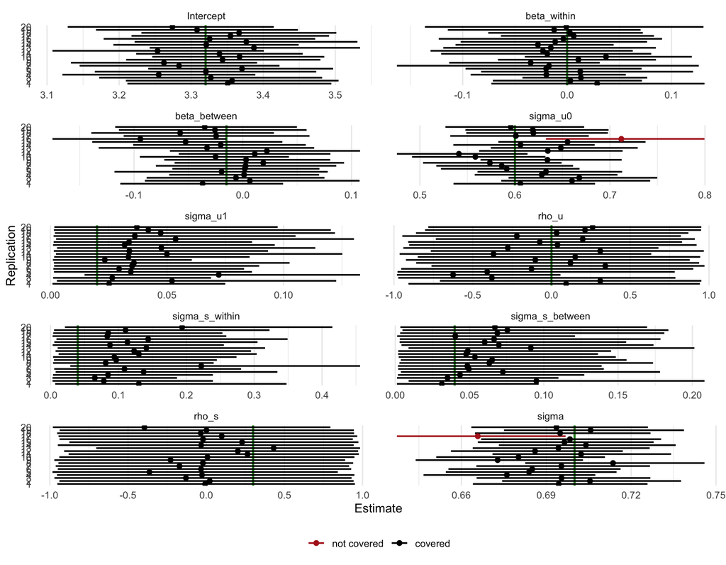

Figure 1: Posterior means and 95% credible intervals for every replication (one row per replication), with the true value as a green line. Panels have their own x-axis.

### Genre Standard Deviations and Their Correlation

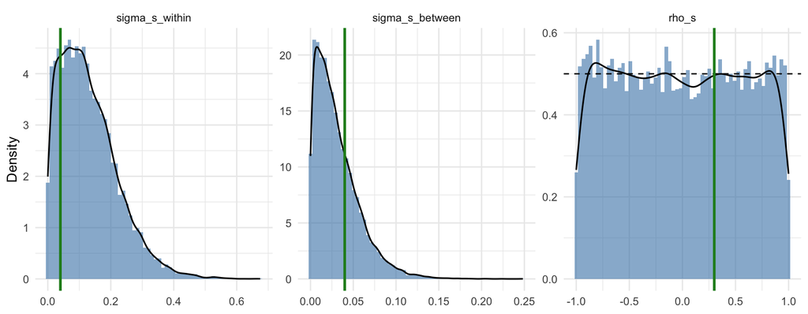

Figure 2: Posterior distributions of the two genre SDs and their correlation in replication 1. Green line: true value. The dashed curve in the correlation panel is the LKJ(1) prior, which for a 2 x 2 correlation matrix is uniform on (-1, 1).

### Genre-Level Slope Adjustments

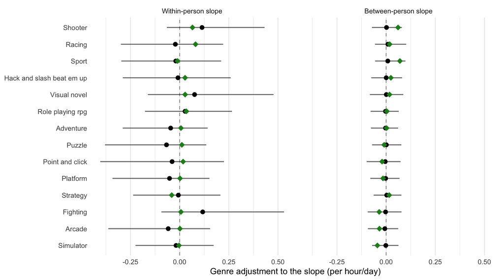

Figure 3: Genre-specific slope adjustments in replication 1: posterior means with 95% credible intervals (black) and the true values drawn for this replication (green diamonds). Estimates are partially pooled towards zero.

| Slope | Adjustments | Covered | Coverage |
| --- | --- | --- | --- |
| Between-person | 280 | 275 | 0.982 |
| Within-person | 280 | 280 | 1.000 |

Table 4: Coverage of the genre-specific adjustments: share of the 14 genre adjustments (per slope type) whose 95% credible interval contains the value drawn for that replication, pooled over replications.

### Convergence Diagnostics

| Replication | Observations | Input draws | Uniform-weight waves (with play) | Max R-hat | Divergent | Max treedepth hits | Min ESS bulk / tail | Minutes (wall / slowest chain) |
| --- | --- | --- | --- | --- | --- | --- | --- | --- |
| 1 | 1200 | 1 | 160 (13) | 1.002 | 0 | 0 | 4060 / 7126 | 8 / 8 |
| 2 | 1200 | 1 | 169 (9) | 1.001 | 0 | 0 | 2651 / 4118 | 8 / 8 |
| 3 | 1200 | 1 | 184 (12) | 1.002 | 0 | 0 | 4557 / 8055 | 8 / 8 |
| 4 | 1200 | 1 | 159 (10) | 1.002 | 0 | 0 | 4267 / 5252 | 9 / 9 |
| 5 | 1200 | 1 | 184 (7) | 1.001 | 0 | 0 | 3145 / 5163 | 8 / 8 |
| 6 | 1200 | 1 | 170 (12) | 1.002 | 0 | 0 | 4989 / 7084 | 8 / 8 |
| 7 | 1200 | 1 | 162 (8) | 1.002 | 0 | 0 | 3116 / 2335 | 8 / 8 |
| 8 | 1200 | 1 | 150 (4) | 1.002 | 0 | 0 | 4541 / 6550 | 9 / 9 |
| 9 | 1200 | 1 | 168 (14) | 1.001 | 0 | 0 | 3545 / 4599 | 8 / 8 |
| 10 | 1200 | 2 | 203 (12) | 1.002 | 0 | 0 | 5131 / 7332 | 10 / 10 |
| 11 | 1200 | 1 | 183 (14) | 1.002 | 0 | 0 | 3250 / 4479 | 10 / 10 |
| 12 | 1200 | 1 | 173 (13) | 1.001 | 0 | 0 | 3747 / 5870 | 10 / 10 |
| 13 | 1200 | 1 | 173 (7) | 1.002 | 0 | 0 | 4055 / 5078 | 8 / 8 |
| 14 | 1200 | 1 | 199 (9) | 1.002 | 0 | 0 | 4685 / 5482 | 11 / 11 |
| 15 | 1200 | 1 | 183 (11) | 1.002 | 0 | 0 | 3731 / 6442 | 9 / 9 |
| 16 | 1200 | 1 | 156 (7) | 1.002 | 0 | 0 | 2649 / 4928 | 14 / 14 |
| 17 | 1200 | 1 | 169 (13) | 1.001 | 0 | 0 | 4150 / 6887 | 10 / 10 |
| 18 | 1200 | 1 | 184 (8) | 1.002 | 0 | 0 | 3755 / 7287 | 10 / 10 |
| 19 | 1200 | 1 | 191 (11) | 1.002 | 0 | 0 | 3326 / 5446 | 11 / 11 |
| 20 | 1200 | 1 | 182 (9) | 1.002 | 0 | 0 | 3277 / 3689 | 9 / 9 |

Table 5: MCMC diagnostics per replication. Input draws: number of simulated inputs needed to pass the guard in mm-data-setup (1 = the first draw passed). ESS: smallest bulk and tail effective sample size over the parameters in the recovery table. Minutes: wall-clock time of the fit, and the run time of the slowest chain.

## Conclusion

Across 20 replications, the 95% credible interval contained the true value in 198 of 200 parameter checks; for the three genre parameters (sigma_s_within, sigma_s_between and rho_s) the count is 60 of 60. For the individual genre adjustments it is 555 of 560. The fits had 0 divergent transitions in total and a largest R-hat of 1.002. Table 3 gives the bias of each posterior mean.

The data were passed to `mm()` in the manuscript’s layout, with constant genre columns and all variation in the weights, and fitted with the manuscript’s formula, priors and sampler control, so these results apply to M4 as it is estimated in the manuscript, at the simulated sample size. Two features of the design should be kept in mind when reading them. First, with 14 genres the genre SDs and especially their correlation are estimated from few units; wide intervals for these parameters reflect that, not a failure of the model. Second, the individual genre adjustments are partially pooled towards zero, so their posterior means are expected to be smaller in magnitude than the drawn values; coverage, not the size of the point estimates, is the relevant check for them.